# WEEKLY_ASSIGNMENT_2_BALMES_I

## WEEKLY_ASSIGNMENT_2_BALMES_I

3.1 Shipments of Household Appliances: Line Graphs. The file ApplianceShipments.csv contains the series of quarterly shipments (in millions of dollars) of US household appliances between 1985 and 1989.

a. Create a well-formatted time plot of the data using Python.

```python
import numpy as np
import pandas as pd
import matplotlib.pylab as plt
```

```python
as_df = pd.read_csv('ApplianceShipments.csv')
```

```python
as_df = as_df.iloc[0:,1:2]
date_range = pd.date_range(start='1/1/1985', end='12/31/1989', freq='Q')
as_df['Date'] = pd.to_datetime(date_range)
```

```python
shipments_ts = pd.Series(as_df.Shipments.values,
index = as_df.Date)
```

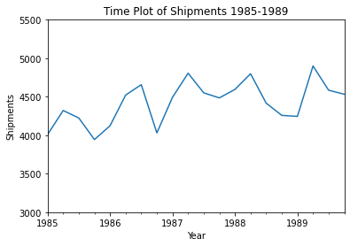

```python
## using pandas
shipments_ts.plot(ylim=[3000, 5500], legend=False)
plt.xlabel('Year') # set x-axis label
plt.ylabel('Shipments') # set y-axis label
plt.title("Time Plot of Shipments 1985-1989")
```

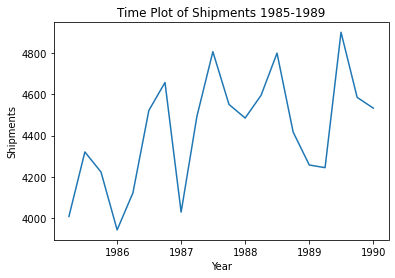

```python
## using matplotlib
plt.plot(shipments_ts.index, shipments_ts)
plt.xlabel('Year') # set x-axis label
plt.ylabel('Shipments') # set y-axis label
plt.title("Time Plot of Shipments 1985-1989")
```

3.2 Sales of Riding Mowers: Scatter Plots. A company that manufactures riding mowers wants to identify the best sales prospects for an intensive sales campaign. In particular, the manufacturer is interested in classifying households as prospective owners or nonowners on the basis of Income (in $1000s) and Lot Size (in 1000 ft2). The marketing expert looked at a random sample of 24 households, given in the file RidingMowers.csv.

a. Using Python, create a scatter plot of Lot Size vs. Income, color-coded by the outcome variable owner/nonowner. Make sure to obtain a well-formatted plot (create legible labels and a legend, etc.)

```python
rm_df = pd.read_csv("C:\\Users\\immba\\Desktop\\IRABALM GBC\\2ND SEMESTER\\BUS4023\\Week2\\RidingMowers.csv")
```

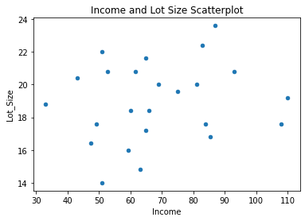

```python
## using pandas
rm_df.plot.scatter(x='Income', y='Lot_Size', legend = True)
plt.title("Income and Lot Size Scatterplot")
```

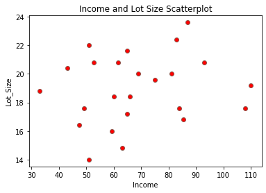

```python
## using matplotlib
plt.scatter(rm_df.Income, rm_df.Lot_Size, color='C5', facecolor='red')
plt.xlabel('Income'); plt.ylabel('Lot_Size')
plt.title("Income and Lot Size Scatterplot")
```

3.3 Laptop Sales at a London Computer Chain: Bar Charts and Boxplots. The file LaptopSalesJanuary2008.csv contains data for all sales of laptops at a computer chain in London in January 2008. This is a subset of the full dataset that includes data for the entire year.

a. Create a bar chart, showing the average retail price by store. Which store has the highest average? Which has the lowest?

```python
ls_df = pd.read_csv("C:\\Users\\immba\\Desktop\\IRABALM GBC\\2ND SEMESTER\\BUS4023\\Week2\\LaptopSalesJanuary2008.csv")
```

```python
ls_df = ls_df.rename(columns={"Retail Price":"Retail_Price"})
ls_df.head(9)
```

|  | Date | Configuration | Customer Postcode | Store Postcode | Retail_Price | Screen Size (Inches) | Battery Life (Hours) | RAM (GB) | Processor Speeds (GHz) | Integrated Wireless? | HD Size (GB) | Bundled Applications? | OS X Customer | OS Y Customer | OS X Store | OS Y Store | CustomerStoreDistance |
| --- | --- | --- | --- | --- | --- | --- | --- | --- | --- | --- | --- | --- | --- | --- | --- | --- | --- |
| 0 | 1/1/2008 0:01 | 163 | EC4V 5BH | SE1 2BN | 455 | 15 | 5 | 1 | 2.0 | Yes | 80 | Yes | 532041 | 180995 | 534057.0 | 179682.0 | 2405.873022 |
| 1 | 1/1/2008 0:02 | 320 | SW4 0JL | SW12 9HD | 545 | 15 | 6 | 1 | 2.0 | No | 300 | No | 529240 | 175537 | 528739.0 | 173080.0 | 2507.558574 |
| 2 | 1/1/2008 0:04 | 23 | EC3V 1LR | E2 0RY | 515 | 15 | 4 | 1 | 2.0 | Yes | 300 | Yes | 533095 | 181047 | 535652.0 | 182961.0 | 3194.001409 |
| 3 | 1/1/2008 0:04 | 169 | SW1P 3AU | SE1 2BN | 395 | 15 | 5 | 1 | 2.0 | No | 40 | Yes | 529902 | 179641 | 534057.0 | 179682.0 | 4155.202281 |
| 4 | 1/1/2008 0:06 | 365 | EC4V 4EG | SW1V 4QQ | 585 | 15 | 6 | 2 | 2.0 | No | 120 | Yes | 531684 | 180948 | 528924.0 | 178440.0 | 3729.298057 |
| 5 | 1/1/2008 0:12 | 309 | W1B 5PX | SW1V 4QQ | 555 | 15 | 6 | 1 | 2.0 | Yes | 120 | Yes | 529207 | 180969 | 528924.0 | 178440.0 | 2544.784863 |
| 6 | 1/1/2008 0:14 | 75 | SE25 4LX | SE8 3JD | 465 | 15 | 4 | 2 | 2.0 | No | 80 | Yes | 534575 | 168236 | 537175.0 | 177885.0 | 9993.157709 |
| 7 | 1/1/2008 0:17 | 346 | N7 6AR | E2 0RY | 450 | 15 | 6 | 2 | 1.5 | No | 40 | No | 530461 | 186176 | 535652.0 | 182961.0 | 6105.956600 |
| 8 | 1/1/2008 0:24 | 70 | W3 7JT | SW18 1NN | 455 | 15 | 4 | 2 | 2.0 | Yes | 120 | No | 520898 | 180071 | 525155.0 | 175180.0 | 6484.129086 |

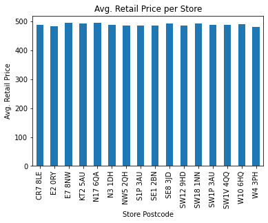

```python
## using pandas
ax = ls_df.groupby('Store Postcode').mean().Retail_Price.plot(kind='bar')
ax.set_ylabel('Avg. Retail Price')
plt.title("Avg. Retail Price per Store")
```

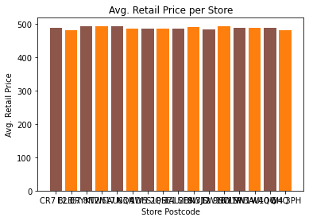

```python
## using matplotlib
dataForPlot = ls_df.groupby('Store Postcode').mean().Retail_Price
fig, ax = plt.subplots()
ax.bar(dataForPlot.index, dataForPlot, color=['C5', 'C1'])
ax.set_xticks([0, 1], True)
ax.set_xlabel('Store Postcode')
ax.set_ylabel('Avg. Retail Price')
plt.title("Avg. Retail Price per Store")
```

*The store with the highest average retail price is Store Postcode N17 6QA; conversely, W4 3PH has the lowest average retail price.*

b. To better compare retail prices across stores, create side-byside boxplots of retail price by store. Now compare the prices in the two stores from (a). Does there seem to be a difference between their price distributions?

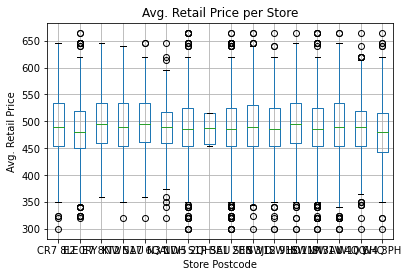

```python
ax = ls_df.boxplot(column='Retail_Price', by='Store Postcode')
ax.set_ylabel('Avg. Retail Price')
plt.suptitle('')
plt.title("Avg. Retail Price per Store")
```

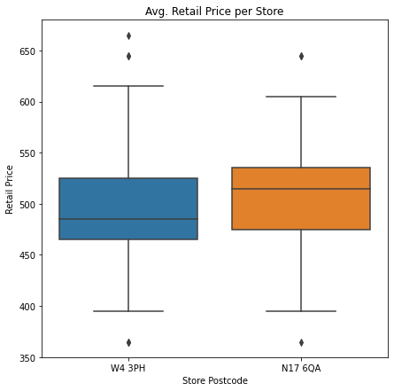

```python
import matplotlib.pyplot as plt
import seaborn as sns
from pandas import read_csv

df = read_csv('C:\\Users\\immba\\Desktop\\IRABALM GBC\\2ND SEMESTER\\BUS4023\\Week2\\LaptopSalesJanuary2008.csv')
df = df[['Retail Price','Store Postcode']]
df = df[(df['Store Postcode'].isin(['N17 6QA','W4 3PH'])) & (df['Retail Price'])]

x = 'Store Postcode'
y = 'Retail Price'

plt.figure(figsize=(7,7))
ax = sns.boxplot(x=x, y=y, data=df)

plt.suptitle('')
plt.title("Avg. Retail Price per Store")

plt.show()
```

*Based on the boxplot, the distributions are relatively similar. However, average retail prices seem to be slightly higher, on average, in store postcode N17 6QA.*